# 6372: Project 2

Edward, Matt, Michael

```r
library(tidyverse)  # general data processing & plotting
library(here)       # relative location references
library(janitor)    # data cleanup tools
library(naniar)     # dealing with missing values
library(caret)      # misc functions for training and plotting classification and regression models
library(tidymodels)
library(GGally)     # for ggpairs
library(MASS)       # for LDA/QDA
```

# EDA From SAS

## Project Portions

- EDA from SAS - **Edward**
- Data Cleanup/Sampling - **Matt**
- Model 1 - **Edward**
- Model 2 Interaction - **???**
- Model 3 LDA - **Matt**
- Model 4 Tree - **Mike**
- Model to Model (of Duration) - **???**

## Summary

### Variables that seem to matter

- **Categorical**: Job, Education, Contact, Month, Marital, Day_of_week, Housing
- **Continuous**: Duration, Campaign, Emp_var_rate, Euribor3m, Nr_employed, Previous

### Variables that don’t seem to matter

- **Categorical**: Default, Loan
- **Continuous**: Age, Cons_price_idx, Cons_conf_idx

### Variables that are junk/incomplete data that doesn’t add explanatory or predictive capabilities

- **Categorical**: Poutcome
- **Continuous**: Pdays

### Missing values

- For categorical, replace with the Mode for each one (listed below)
- For continuous, only Pdays is missing, and we should delete it, but for completeness, replace with median (6)
- VIF: Variable Inflation Factor
  - Emp_var_rate, Euribor3m, Nr_employed, Cons_price_idx, and Cons_conf_idx are all really just measures of time.
  - They coordinate heavily with “what is the month”
  - PCA should reveal that all of these continuous variables can be coordinated together and further, the month tells you the results as a category
  - Alternately, ignore the month and use these variables to predict, but don’t use both

## Categorical Variables

### PROC FREQ

- **Average**: No=88.7, %Yes=11.3%
- **Total responses**: 41,188
- **Job**
  - Very strong
  - Above average: student 31%, retired 25%, Unemployed 14%
  - Below average: entrepreneur 8.5%, services 8%, blue-collar 7%
  - Mode: Admin 10,422
  - p-value < 0.0001
- **Marital**
  - Above average: Single 14%
  - Below average: married, 10.2%, divorced 10.3%
  - Mode: married 24,928
  - p-value < 0.0001
- **Education**
  - Above average: illiterate 22%, university degree 14%
  - Below average: Basic 9y 7.8%, Basic 6y 8.2%, Basic 4y 10.3%
  - Mode: university degree 12,168
  - p-value < 0.0001
- **Default** - Should definitely ignore this field
  - Mode: No, 32,588 (only 3 yes’ in the whole dataset)
  - p-value < 0.5054
- **Housing**
  - Above average: Yes 11.6%
  - Below average: No 10.9%
  - Mode: Yes 21,576
  - p-value < 0.02
- **Loan** - Does not seem to be statistically significant
  - Above average: No 11.3%
  - Below average: Yes 10.9%
  - Mode: No 33,950
  - p-value = 0.3479
- **Contact**
  - Above average: Cellular 15%
  - Below average: telephone 5%
  - Mode: Cellular 26,144
  - p-value < 0.0001
- **Month**
  - Above average: Mar 51%, Dec 49%, Sep 45%, Oct 44%, Apr 20% [So basically, Sep-Mar except Nov is odd]
  - Below average: May 6%, Jul 9%, Nov 10%, Jun 10.5%, Aug 10.6%
  - Not in dataset: Jan, Feb
  - Mode: May 13,769
  - No Missing Data
  - p-value < 0.0001
- **Day of Week**
  - Above average: Thu 12.1%, Tue 11.8%, Wed 11.7%
  - Below average: Mon 10%, Fri 10.8%
  - Not in dataset: Sat, Sun
  - Mode: Thu 8,623
  - No Missing Data
  - p-value < 0.0001
- **Poutcome**
  - Somewhat misleading variable (when it’s present which isn’t very often, Yes is above average in both cases)
  - Above average: Success 65%, Failure 14%
  - Below average: NONE (see note above)
  - Mode: Failure 4,252
  - p-value < 0.0001

## Continuous Variables

### PROC MEANS

- **Counts**
  - No=36,548, Yes=4,640
  - Only continuous variable with missing values is PDAYS
- **Total responses**: 41,188
- **age**
  - No: Mean 39.9, Median 38
  - Yes: Mean 40.9, Median 37
- **duration**
  - No: Mean 221, Median 164, Min 0
  - Yes: Mean 553, Median 449, Min 37
  - Longer the call, the more Yes increases
  - If the call lasts 36 or fewer seconds, it is No 100% of the time
- **campaign**
  - No: Mean 2.6, Max 56
  - Yes: Mean 2.0, Max 23
  - Median: 2 (for both yes and no)
  - Fewer the campaigns, the more Yes increases - If there are more than 23 campaigns, it is No 100% of the time
- **pdays**
  - Recommend we discard this variable
  - Massive missing continuous variable
  - No real difference between continuous values for yes and no, but:
  - Misleading: when variable exists, Yes is the outcome for Subscribed 64% of the time
  - Median: 6 (for both yes and no)
- **previous**
  - No: Mean 0.13
  - Yes: Mean 0.49
  - Median: 0 (for both yes and no)
- **emp_var_rate**
  - No: Mean 0.25, Median 1.1
  - Yes: Mean -1.2, Median -1.8
  - The lower the emp_var_rate, the more likely to get a Yes. In other words, negatively correlated.
- **cons_price_idx**
  - Doesn’t seem to be very significant
  - No: Mean 94, Median 94
  - Yes: Mean 93, Median 93
- **cons_conf_idx**
  - Doesn’t seem to be very significant
  - No: Mean -41, Median -42
  - Yes: Mean -40, Median -40
- **euribor3m**
  - No: Mean 3.8, Median 4.9
  - Yes: Mean 2.1, Median 1.3
  - The lower the euribor3m interest rate, the more likely to get a Yes. In other words, negatively correlated.
- **nr_employed**
  - No: Mean 5176, Median 5196
  - Yes: Mean 5095, Median 5099
  - The lower the nr_employed rate, the more likely to get a Yes. In other words, negatively correlated.

# Load Data

```r
# Read data
bank <- read_delim(here("data - raw", "bank-additional", "bank-additional-full.csv"),
                   ";", escape_double = FALSE, trim_ws = TRUE)

# Clean column names
bank <- clean_names(bank)

# Quick examination of the data
glimpse(bank)
```

```
## Rows: 41,188
## Columns: 21
## $ age            <dbl> 56, 57, 37, 40, 56, 45, 59, 41, 24, 25, 41, 25, 29, 57…
## $ job            <chr> "housemaid", "services", "services", "admin.", "servic…
## $ marital        <chr> "married", "married", "married", "married", "married",…
## $ education      <chr> "basic.4y", "high.school", "high.school", "basic.6y", …
## $ default        <chr> "no", "unknown", "no", "no", "no", "unknown", "no", "u…
## $ housing        <chr> "no", "no", "yes", "no", "no", "no", "no", "no", "yes"…
## $ loan           <chr> "no", "no", "no", "no", "yes", "no", "no", "no", "no",…
## $ contact        <chr> "telephone", "telephone", "telephone", "telephone", "t…
## $ month          <chr> "may", "may", "may", "may", "may", "may", "may", "may"…
## $ day_of_week    <chr> "mon", "mon", "mon", "mon", "mon", "mon", "mon", "mon"…
## $ duration       <dbl> 261, 149, 226, 151, 307, 198, 139, 217, 380, 50, 55, 2…
## $ campaign       <dbl> 1, 1, 1, 1, 1, 1, 1, 1, 1, 1, 1, 1, 1, 1, 1, 1, 1, 1, …
## $ pdays          <dbl> 999, 999, 999, 999, 999, 999, 999, 999, 999, 999, 999,…
## $ previous       <dbl> 0, 0, 0, 0, 0, 0, 0, 0, 0, 0, 0, 0, 0, 0, 0, 0, 0, 0, …
## $ poutcome       <chr> "nonexistent", "nonexistent", "nonexistent", "nonexist…
## $ emp_var_rate   <dbl> 1.1, 1.1, 1.1, 1.1, 1.1, 1.1, 1.1, 1.1, 1.1, 1.1, 1.1,…
## $ cons_price_idx <dbl> 93.994, 93.994, 93.994, 93.994, 93.994, 93.994, 93.994…
## $ cons_conf_idx  <dbl> -36.4, -36.4, -36.4, -36.4, -36.4, -36.4, -36.4, -36.4…
## $ euribor3m      <dbl> 4.857, 4.857, 4.857, 4.857, 4.857, 4.857, 4.857, 4.857…
## $ nr_employed    <dbl> 5191, 5191, 5191, 5191, 5191, 5191, 5191, 5191, 5191, …
## $ y              <chr> "no", "no", "no", "no", "no", "no", "no", "no", "no", …
```

```r
head(bank)
```

```
## # A tibble: 6 x 21
##     age job   marital education default housing loan  contact month day_of_week
##   <dbl> <chr> <chr>   <chr>     <chr>   <chr>   <chr> <chr>   <chr> <chr>
## 1    56 hous… married basic.4y  no      no      no    teleph… may   mon
## 2    57 serv… married high.sch… unknown no      no    teleph… may   mon
## 3    37 serv… married high.sch… no      yes     no    teleph… may   mon
## 4    40 admi… married basic.6y  no      no      no    teleph… may   mon
## 5    56 serv… married high.sch… no      no      yes   teleph… may   mon
## 6    45 serv… married basic.9y  unknown no      no    teleph… may   mon
## # … with 11 more variables: duration <dbl>, campaign <dbl>, pdays <dbl>,
## #   previous <dbl>, poutcome <chr>, emp_var_rate <dbl>, cons_price_idx <dbl>,
## #   cons_conf_idx <dbl>, euribor3m <dbl>, nr_employed <dbl>, y <chr>
```

## Attribute Information ([source](https://archive.ics.uci.edu/ml/datasets/Bank%20Marketing))

### Bank Client Data

1. **age**
2. **job**: type of job
3. **marital**: marital status
4. **education**
5. **default**: has credit in default?
6. **housing**: has housing loan?
7. **loan**: has personal loan?

### Related with the Last Contact of the Current Campaign

8. **contact**: contact communication type
9. **month**: last contact month of year
10. **day_of_week**: last contact day of the week
11. **duration**: last contact duration, in seconds. Important note: this attribute highly affects the output target (e.g., if duration=0 then y=‘no’). Yet, the duration is not known before a call is performed. Also, after the end of the call y is obviously known. Thus, this input should only be included for benchmark purposes and should be discarded if the intention is to have a realistic predictive model.

### Other Attributes

12. **campaign**: number of contacts performed during this campaign and for this client (includes last contact)
13. **pdays**: number of days that passed by after the client was last contacted from a previous campaign (999 means client was not previously contacted)
14. **previous**: number of contacts performed before this campaign and for this client
15. **poutcome**: outcome of the previous marketing campaign

### Social and Economic Context Attributes

16. **emp.var.rate**: employment variation rate - quarterly indicator
17. **cons.price.idx**: consumer price index - monthly indicator
18. **cons.conf.idx**: consumer confidence index - monthly indicator
19. **euribor3m**: euribor 3 month rate - daily indicator
20. **nr.employed**: number of employees - quarterly indicator

### Output Variable (Desired Target)

21. **y**: has the client subscribed to a term deposit?

# Address Missing Values

## Categorical Variables

```r
# Begin by replacing missing value placeholders with NA
bank_clean <- bank %>%
  replace_with_na_all(condition = ~ .x == "unknown") %>%
  replace_with_na(replace = list(pdays = 999)) %>%
  replace_with_na(replace = list(poutcome = "nonexistent"))

# Replace each missing value in a categorical variable with the mode as
# determined during SAS EDA
bank_clean <- bank_clean %>%
  mutate(job         = replace_na(job,         "admin."),
         marital     = replace_na(marital,     "married"),
         housing     = replace_na(housing,     "yes"),
         loan        = replace_na(loan,        "no"),
         contact     = replace_na(contact,     "cellular"),
         education   = replace_na(education,   "university.degree"),
         month       = replace_na(month,       "may"),
         day_of_week = replace_na(day_of_week, "thu"),
         poutcome    = replace_na(poutcome,    "failure"))

# Drop `default` column since there are only 3 "Yes" values
bank_clean <- bank_clean %>%
  dplyr::select(-default)
```

## Continuous Variables

```r
# Only Pdays is missing, and we should delete it, but for completeness, replace
# with median (6)
bank_clean <- bank_clean %>%
  mutate(pdays = replace_na(pdays, 6))
```

## Additional Cleanup

```r
# Rename response variable
bank_clean <- bank_clean %>%
  rename(subscribed = y)

# Convert all character variables to factors
bank_clean <- bank_clean %>%
  mutate(across(where(is_character),as_factor))
```

# Post-Cleanup Examination

```r
# Re-run reports
DataExplorer::create_report(bank_clean)
```

[output not shown]

[output not shown]

[output not shown]

[output not shown]

[output not shown]

[output not shown]

[output not shown]

[output not shown]

```r
Hmisc::describe(bank_clean)
```

```
## bank_clean
##
##  20  Variables      41188  Observations
## --------------------------------------------------------------------------------
## age
##        n  missing distinct     Info     Mean      Gmd      .05      .10
##    41188        0       78    0.999    40.02    11.57       26       28
##      .25      .50      .75      .90      .95
##       32       38       47       55       58
##
## lowest : 17 18 19 20 21, highest: 91 92 94 95 98
## --------------------------------------------------------------------------------
## job
##        n  missing distinct
##    41188        0       11
##
## lowest : housemaid     services      admin.        blue-collar   technician
## highest: management    unemployed    self-employed entrepreneur  student
##
## housemaid (1060, 0.026), services (3969, 0.096), admin. (10752, 0.261),
## blue-collar (9254, 0.225), technician (6743, 0.164), retired (1720, 0.042),
## management (2924, 0.071), unemployed (1014, 0.025), self-employed (1421,
## 0.035), entrepreneur (1456, 0.035), student (875, 0.021)
## --------------------------------------------------------------------------------
## marital
##        n  missing distinct
##    41188        0        3
##
## Value       married   single divorced
## Frequency     25008    11568     4612
## Proportion    0.607    0.281    0.112
## --------------------------------------------------------------------------------
## education
##        n  missing distinct
##    41188        0        7
##
## lowest : basic.4y            high.school         basic.6y            basic.9y            professional.course
## highest: basic.6y            basic.9y            professional.course university.degree   illiterate
##
## basic.4y (4176, 0.101), high.school (9515, 0.231), basic.6y (2292, 0.056),
```

[output cut: 134 more lines]

```
## Frequency     635    773    650   1071    172   1663   8534     10   7763
## Proportion  0.015  0.019  0.016  0.026  0.004  0.040  0.207  0.000  0.188
##
## Value      5195.8 5228.1
## Frequency    3683  16234
## Proportion  0.089  0.394
## --------------------------------------------------------------------------------
## subscribed
##        n  missing distinct
##    41188        0        2
##
## Value         no   yes
## Frequency  36548  4640
## Proportion 0.887 0.113
## --------------------------------------------------------------------------------
```

```r
psych::describe(bank_clean)
```

```
##                vars     n    mean     sd  median trimmed    mad     min     max
## age               1 41188   40.02  10.42   38.00   39.30  10.38   17.00   98.00
## job*              2 41188    4.56   2.26    4.00    4.27   1.48    1.00   11.00
## marital*          3 41188    1.50   0.69    1.00    1.38   0.00    1.00    3.00
## education*        4 41188    3.98   1.84    4.00    4.10   2.97    1.00    7.00
## housing*          5 41188    1.55   0.50    2.00    1.56   0.00    1.00    2.00
## loan*             6 41188    1.15   0.36    1.00    1.06   0.00    1.00    2.00
## contact*          7 41188    1.63   0.48    2.00    1.67   0.00    1.00    2.00
## month*            8 41188    3.25   2.43    3.00    2.84   2.97    1.00   10.00
## day_of_week*      9 41188    2.98   1.41    3.00    2.97   1.48    1.00    5.00
## duration         10 41188  258.29 259.28  180.00  210.61 139.36    0.00 4918.00
## campaign         11 41188    2.57   2.77    2.00    1.99   1.48    1.00   56.00
## pdays            12 41188    6.00   0.73    6.00    6.00   0.00    0.00   27.00
## previous         13 41188    0.17   0.49    0.00    0.05   0.00    0.00    7.00
## poutcome*        14 41188    1.03   0.18    1.00    1.00   0.00    1.00    2.00
## emp_var_rate     15 41188    0.08   1.57    1.10    0.27   0.44   -3.40    1.40
## cons_price_idx   16 41188   93.58   0.58   93.75   93.58   0.56   92.20   94.77
## cons_conf_idx    17 41188  -40.50   4.63  -41.80  -40.60   6.52  -50.80  -26.90
## euribor3m        18 41188    3.62   1.73    4.86    3.81   0.16    0.63    5.04
## nr_employed      19 41188 5167.04  72.25 5191.00 5178.43  55.00 4963.60 5228.10
## subscribed*      20 41188    1.11   0.32    1.00    1.02   0.00    1.00    2.00
##                  range  skew kurtosis   se
## age              81.00  0.78     0.79 0.05
## job*             10.00  1.10     0.72 0.01
## marital*          2.00  1.01    -0.26 0.00
## education*        6.00 -0.26    -1.47 0.01
## housing*          1.00 -0.19    -1.96 0.00
## loan*             1.00  1.94     1.77 0.00
## contact*          1.00 -0.56    -1.69 0.00
## month*            9.00  1.13     0.48 0.01
## day_of_week*      4.00  0.00    -1.30 0.01
## duration       4918.00  3.26    20.24 1.28
## campaign         55.00  4.76    36.97 0.01
## pdays            27.00  7.65   148.52 0.00
## previous          7.00  3.83    20.11 0.00
## poutcome*         1.00  5.20    25.03 0.00
## emp_var_rate      4.80 -0.72    -1.06 0.01
## cons_price_idx    2.57 -0.23    -0.83 0.00
## cons_conf_idx    23.90  0.30    -0.36 0.02
## euribor3m         4.41 -0.71    -1.41 0.01
## nr_employed     264.50 -1.04     0.00 0.36
## subscribed*       1.00  2.45     4.00 0.00
```

```r
skimr::skim(bank_clean)
```

Data summary

| Name | bank_clean |
| --- | --- |
| Number of rows | 41188 |
| Number of columns | 20 |
| _______________________ |  |
| Column type frequency: |  |
| factor | 10 |
| numeric | 10 |
| ________________________ |  |
| Group variables | None |

**Variable type: factor**

| skim_variable | n_missing | complete_rate | ordered | n_unique | top_counts |
| --- | --- | --- | --- | --- | --- |
| job | 0 | 1 | FALSE | 11 | adm: 10752, blu: 9254, tec: 6743, ser: 3969 |
| marital | 0 | 1 | FALSE | 3 | mar: 25008, sin: 11568, div: 4612 |
| education | 0 | 1 | FALSE | 7 | uni: 13899, hig: 9515, bas: 6045, pro: 5243 |
| housing | 0 | 1 | FALSE | 2 | yes: 22566, no: 18622 |
| loan | 0 | 1 | FALSE | 2 | no: 34940, yes: 6248 |
| contact | 0 | 1 | FALSE | 2 | cel: 26144, tel: 15044 |
| month | 0 | 1 | FALSE | 10 | may: 13769, jul: 7174, aug: 6178, jun: 5318 |
| day_of_week | 0 | 1 | FALSE | 5 | thu: 8623, mon: 8514, wed: 8134, tue: 8090 |
| poutcome | 0 | 1 | FALSE | 2 | fai: 39815, suc: 1373 |
| subscribed | 0 | 1 | FALSE | 2 | no: 36548, yes: 4640 |

**Variable type: numeric**

| skim_variable | n_missing | complete_rate | mean | sd | p0 | p25 | p50 | p75 | p100 | hist |
| --- | --- | --- | --- | --- | --- | --- | --- | --- | --- | --- |
| age | 0 | 1 | 40.02 | 10.42 | 17.00 | 32.00 | 38.00 | 47.00 | 98.00 | ▅▇▃▁▁ |
| duration | 0 | 1 | 258.29 | 259.28 | 0.00 | 102.00 | 180.00 | 319.00 | 4918.00 | ▇▁▁▁▁ |
| campaign | 0 | 1 | 2.57 | 2.77 | 1.00 | 1.00 | 2.00 | 3.00 | 56.00 | ▇▁▁▁▁ |
| pdays | 0 | 1 | 6.00 | 0.73 | 0.00 | 6.00 | 6.00 | 6.00 | 27.00 | ▁▇▁▁▁ |
| previous | 0 | 1 | 0.17 | 0.49 | 0.00 | 0.00 | 0.00 | 0.00 | 7.00 | ▇▁▁▁▁ |
| emp_var_rate | 0 | 1 | 0.08 | 1.57 | -3.40 | -1.80 | 1.10 | 1.40 | 1.40 | ▁▃▁▁▇ |
| cons_price_idx | 0 | 1 | 93.58 | 0.58 | 92.20 | 93.08 | 93.75 | 93.99 | 94.77 | ▁▆▃▇▂ |
| cons_conf_idx | 0 | 1 | -40.50 | 4.63 | -50.80 | -42.70 | -41.80 | -36.40 | -26.90 | ▅▇▁▇▁ |
| euribor3m | 0 | 1 | 3.62 | 1.73 | 0.63 | 1.34 | 4.86 | 4.96 | 5.04 | ▅▁▁▁▇ |
| nr_employed | 0 | 1 | 5167.04 | 72.25 | 4963.60 | 5099.10 | 5191.00 | 5228.10 | 5228.10 | ▁▁▃▁▇ |

```r
# Reports from inspectdf (categorical variables and Pearson correlation
# coefficients)
bank_cat  <- inspectdf::inspect_cat(bank_clean)
bank_pear <- inspectdf::inspect_cor(bank_clean)
```

# Create Test/Train Splits and Save Data

```r
# Set seed
set.seed(123)

# Save full bank_clean data set
# write_csv(bank_clean, here("data - output", "bank_clean.csv"))

# Create test/train data sets of full data
inTraining <- createDataPartition(bank_clean$subscribed, p = .75, list = FALSE)
training <- bank_clean[ inTraining,]
testing  <- bank_clean[-inTraining,]

# Save bank_clean test/train sets
# write_csv(training, here("data - output", "bank_clean_train.csv"))
# write_csv(testing, here("data - output", "bank_clean_test.csv"))

# Down-sample the data to get an equal number of yes and no responses
bank_clean_ds <- downSample(x = bank_clean[, 1:19],
                            y = bank_clean$subscribed)

# Rename `Class` to `subscribed`
bank_clean_ds <- bank_clean_ds %>%
  rename(subscribed = Class)

# Double-check the number of yes/no responses
bank_clean_ds %>%
  count(subscribed)
```

```
##   subscribed    n
## 1         no 4640
## 2        yes 4640
```

```r
# Save downsampled data set
# write_csv(bank_clean_ds, here("data - output", "bank_clean_downsampled.csv"))

# Create test/train data sets of downsampled data
inTraining <- createDataPartition(bank_clean_ds$subscribed, p = .75, list = FALSE)
training <- bank_clean_ds[ inTraining,]
testing  <- bank_clean_ds[-inTraining,]

# Save downsampled data test/train sets
# write_csv(training, here("data - output", "bank_clean_ds_train.csv"))
# write_csv(testing, here("data - output", "bank_clean_ds_test.csv"))
```

# LDA/QDA Model

## LDA

```r
set.seed(123)

# Create LDA data set
lda_data <- bank_clean_ds %>%
  dplyr::select(c(1, 10:13, 15:17, 19:20)) # class + numeric columns + drop euribor3m

# Check for collinearity
view(inspectdf::inspect_cor(lda_data))

# Create test/train data sets of downsampled data
inTraining <- createDataPartition(lda_data$subscribed, p = .75, list = FALSE)
training <- lda_data[ inTraining,]
testing  <- lda_data[-inTraining,]

# Estimate preprocessing parameters
preproc_parameter <- training %>%
  preProcess(method = c("center", "scale"))

# Transform the data using the estimated parameters
train_transform <- preproc_parameter %>% predict(training)
test_transform <- preproc_parameter %>% predict(testing)

# Fit the model
lda_model <- lda(subscribed ~ ., data = train_transform)

# Look at the model
lda_model
```

```
## Call:
## lda(subscribed ~ ., data = train_transform)
##
## Prior probabilities of groups:
##  no yes
## 0.5 0.5
##
## Group means:
##             age   duration   campaign       pdays  previous emp_var_rate
## no  -0.05765319 -0.4618798  0.1216407  0.01234911 -0.262436    0.4363607
## yes  0.05765319  0.4618798 -0.1216407 -0.01234911  0.262436   -0.4363607
##     cons_price_idx cons_conf_idx nr_employed
## no        0.195229   -0.07381196   0.4718173
## yes      -0.195229    0.07381196  -0.4718173
##
## Coefficients of linear discriminants:
##                        LD1
## age             0.03011647
## duration        0.99282699
## campaign       -0.03297621
## pdays          -0.02574252
## previous        0.08658940
## emp_var_rate   -0.67645804
## cons_price_idx  0.20689995
## cons_conf_idx   0.15549357
## nr_employed    -0.41222502
```

```r
# Make predictions
lda_predictions <- lda_model %>% predict(test_transform)

# Model accuracy
mean(lda_predictions$class == test_transform$subscribed)
```

```
## [1] 0.8262931
```

```r
# Generate confusion matrix
confusionMatrix(predict(lda_model, newdata = test_transform)$class,
                test_transform$subscribed)
```

```
## Confusion Matrix and Statistics
##
##           Reference
## Prediction  no yes
##        no  978 221
##        yes 182 939
##
##                Accuracy : 0.8263
##                  95% CI : (0.8103, 0.8415)
##     No Information Rate : 0.5
##     P-Value [Acc > NIR] : < 2e-16
##
##                   Kappa : 0.6526
##
##  Mcnemar's Test P-Value : 0.05837
##
##             Sensitivity : 0.8431
##             Specificity : 0.8095
##          Pos Pred Value : 0.8157
##          Neg Pred Value : 0.8376
##              Prevalence : 0.5000
##          Detection Rate : 0.4216
##    Detection Prevalence : 0.5168
##       Balanced Accuracy : 0.8263
##
##        'Positive' Class : no
##
```

```r
# Get the posteriors as a tibble
lda_posteriors <- tibble(predict(lda_model, newdata = test_transform)$posterior)

# Create prediction and performance values
library(ROCR)
lda_predict <- prediction(lda_predictions$posterior[,2], test_transform$subscribed)
lda_perf    <- performance(lda_predict, "tpr", "fpr")

# Calculate AUC
lda_auc <- performance(lda_predict, measure = "auc")
lda_auc <- lda_auc@y.values[[1]]
lda_auc
```

```
## [1] 0.9126301
```

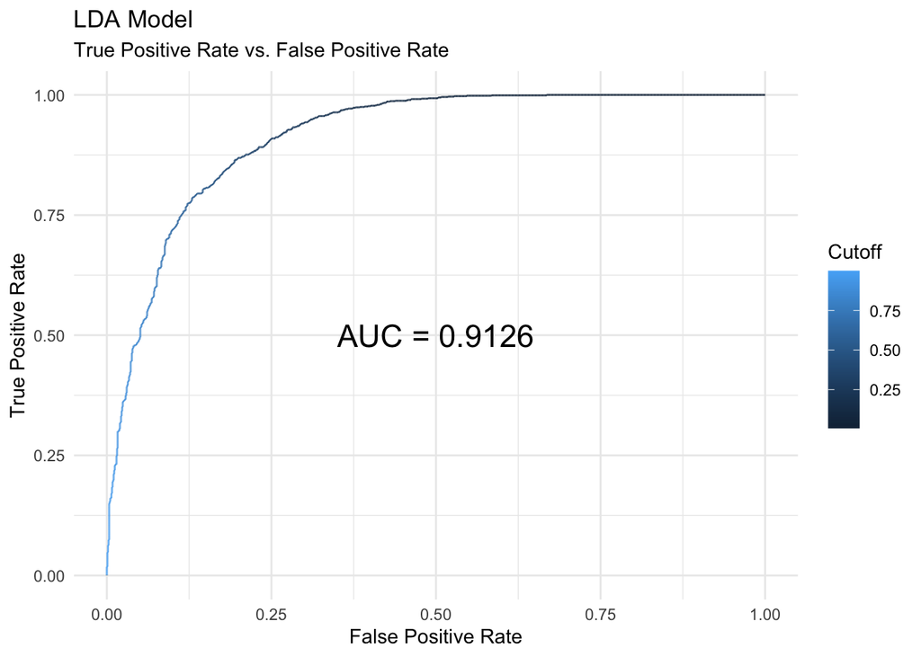

```r
# Create and plot ROC curve for LDA model
library(ggfortify)
autoplot(lda_perf) +
  labs(title = "LDA Model",
       subtitle = "True Positive Rate vs. False Positive Rate",
       x = "False Positive Rate",
       y = "True Positive Rate") +
  annotate(
    geom = "text", x = 0.50, y = 0.50,
    label = paste("AUC =", round(lda_auc, 4)), size = 6
  ) +
  theme_minimal()
```

## QDA

```r
# QDA
qda_model <- qda(subscribed ~ ., data = train_transform)

# Make predictions
qda_predictions <- qda_model %>% predict(test_transform)

# Model accuracy
mean(qda_predictions$class == test_transform$subscribed)
```

```
## [1] 0.7831897
```

```r
# Generate confusion matrix
confusionMatrix(predict(qda_model, newdata = test_transform)$class,
                test_transform$subscribed)
```

```
## Confusion Matrix and Statistics
##
##           Reference
## Prediction   no  yes
##        no  1049  392
##        yes  111  768
##
##                Accuracy : 0.7832
##                  95% CI : (0.7659, 0.7998)
##     No Information Rate : 0.5
##     P-Value [Acc > NIR] : < 2.2e-16
##
##                   Kappa : 0.5664
##
##  Mcnemar's Test P-Value : < 2.2e-16
##
##             Sensitivity : 0.9043
##             Specificity : 0.6621
##          Pos Pred Value : 0.7280
##          Neg Pred Value : 0.8737
##              Prevalence : 0.5000
##          Detection Rate : 0.4522
##    Detection Prevalence : 0.6211
##       Balanced Accuracy : 0.7832
##
##        'Positive' Class : no
##
```

```r
# Get the posteriors as a tibble
qda_posteriors <- tibble(predict(qda_model, newdata = test_transform)$posterior)

# Create prediction and performance values
qda_predict <- prediction(qda_predictions$posterior[,2], test_transform$subscribed)
qda_perf    <- performance(qda_predict, "tpr", "fpr")

# Calculate AUC
qda_auc <- performance(qda_predict, measure = "auc")
qda_auc <- qda_auc@y.values[[1]]
qda_auc
```

```
## [1] 0.8996882
```

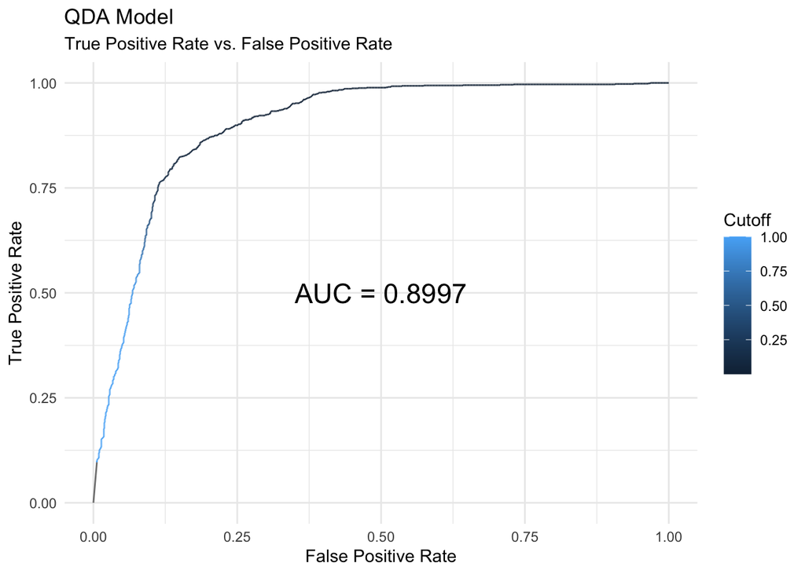

```r
# Create and plot ROC curve for LDA model
autoplot(qda_perf) +
  labs(title = "QDA Model",
       subtitle = "True Positive Rate vs. False Positive Rate",
       x = "False Positive Rate",
       y = "True Positive Rate") +
    annotate(
    geom = "text", x = 0.50, y = 0.50,
    label = paste("AUC =", round(qda_auc, 4)), size = 6
  ) +
  theme_minimal()
```

# Appendix

## R Code

```r
knitr::opts_chunk$set(echo = TRUE)
knitr::opts_chunk$set(warning = FALSE)
knitr::opts_chunk$set(message = FALSE)
library(tidyverse)  # general data processing & plotting
library(here)       # relative location references
library(janitor)    # data cleanup tools
library(naniar)     # dealing with missing values
library(caret)      # misc functions for training and plotting classification and regression models
library(tidymodels)
library(GGally)     # for ggpairs
library(MASS)       # for LDA/QDA
# Read data
bank <- read_delim(here("data - raw", "bank-additional", "bank-additional-full.csv"),
                   ";", escape_double = FALSE, trim_ws = TRUE)

# Clean column names
bank <- clean_names(bank)

# Quick examination of the data
glimpse(bank)
head(bank)
# Begin by replacing missing value placeholders with NA
bank_clean <- bank %>%
  replace_with_na_all(condition = ~ .x == "unknown") %>%
  replace_with_na(replace = list(pdays = 999)) %>%
  replace_with_na(replace = list(poutcome = "nonexistent"))

# Replace each missing value in a categorical variable with the mode as
# determined during SAS EDA
bank_clean <- bank_clean %>%
  mutate(job         = replace_na(job,         "admin."),
         marital     = replace_na(marital,     "married"),
         housing     = replace_na(housing,     "yes"),
         loan        = replace_na(loan,        "no"),
         contact     = replace_na(contact,     "cellular"),
         education   = replace_na(education,   "university.degree"),
         month       = replace_na(month,       "may"),
         day_of_week = replace_na(day_of_week, "thu"),
         poutcome    = replace_na(poutcome,    "failure"))

# Drop `default` column since there are only 3 "Yes" values
bank_clean <- bank_clean %>%
  dplyr::select(-default)
# Only Pdays is missing, and we should delete it, but for completeness, replace
# with median (6)
bank_clean <- bank_clean %>%
  mutate(pdays = replace_na(pdays, 6))
# Rename response variable
bank_clean <- bank_clean %>%
  rename(subscribed = y)

# Convert all character variables to factors
bank_clean <- bank_clean %>%
  mutate(across(where(is_character),as_factor))
# Re-run reports
DataExplorer::create_report(bank_clean)
Hmisc::describe(bank_clean)
psych::describe(bank_clean)
skimr::skim(bank_clean)

# Reports from inspectdf (categorical variables and Pearson correlation
# coefficients)
bank_cat  <- inspectdf::inspect_cat(bank_clean)
bank_pear <- inspectdf::inspect_cor(bank_clean)
# Set seed
set.seed(123)

# Save full bank_clean data set
# write_csv(bank_clean, here("data - output", "bank_clean.csv"))

# Create test/train data sets of full data
inTraining <- createDataPartition(bank_clean$subscribed, p = .75, list = FALSE)
training <- bank_clean[ inTraining,]
testing  <- bank_clean[-inTraining,]

# Save bank_clean test/train sets
# write_csv(training, here("data - output", "bank_clean_train.csv"))
# write_csv(testing, here("data - output", "bank_clean_test.csv"))

# Down-sample the data to get an equal number of yes and no responses
bank_clean_ds <- downSample(x = bank_clean[, 1:19],
                            y = bank_clean$subscribed)

# Rename `Class` to `subscribed`
bank_clean_ds <- bank_clean_ds %>%
  rename(subscribed = Class)

# Double-check the number of yes/no responses
bank_clean_ds %>%
  count(subscribed)

# Save downsampled data set
# write_csv(bank_clean_ds, here("data - output", "bank_clean_downsampled.csv"))

# Create test/train data sets of downsampled data
inTraining <- createDataPartition(bank_clean_ds$subscribed, p = .75, list = FALSE)
training <- bank_clean_ds[ inTraining,]
testing  <- bank_clean_ds[-inTraining,]

# Save downsampled data test/train sets
# write_csv(training, here("data - output", "bank_clean_ds_train.csv"))
# write_csv(testing, here("data - output", "bank_clean_ds_test.csv"))
set.seed(123)

# Create LDA data set
lda_data <- bank_clean_ds %>%
  dplyr::select(c(1, 10:13, 15:17, 19:20)) # class + numeric columns + drop euribor3m

# Check for collinearity
view(inspectdf::inspect_cor(lda_data))

# Create test/train data sets of downsampled data
inTraining <- createDataPartition(lda_data$subscribed, p = .75, list = FALSE)
training <- lda_data[ inTraining,]
testing  <- lda_data[-inTraining,]

# Estimate preprocessing parameters
preproc_parameter <- training %>%
  preProcess(method = c("center", "scale"))

# Transform the data using the estimated parameters
train_transform <- preproc_parameter %>% predict(training)
test_transform <- preproc_parameter %>% predict(testing)

# Fit the model
lda_model <- lda(subscribed ~ ., data = train_transform)

# Look at the model
lda_model

# Make predictions
lda_predictions <- lda_model %>% predict(test_transform)

# Model accuracy
mean(lda_predictions$class == test_transform$subscribed)

# Generate confusion matrix
confusionMatrix(predict(lda_model, newdata = test_transform)$class,
                test_transform$subscribed)

# Get the posteriors as a tibble
lda_posteriors <- tibble(predict(lda_model, newdata = test_transform)$posterior)

# Create prediction and performance values
library(ROCR)
lda_predict <- prediction(lda_predictions$posterior[,2], test_transform$subscribed)
lda_perf    <- performance(lda_predict, "tpr", "fpr")

# Calculate AUC
lda_auc <- performance(lda_predict, measure = "auc")
lda_auc <- lda_auc@y.values[[1]]
lda_auc

# Create and plot ROC curve for LDA model
library(ggfortify)
autoplot(lda_perf) +
  labs(title = "LDA Model",
       subtitle = "True Positive Rate vs. False Positive Rate",
       x = "False Positive Rate",
       y = "True Positive Rate") +
  annotate(
    geom = "text", x = 0.50, y = 0.50,
    label = paste("AUC =", round(lda_auc, 4)), size = 6
  ) +
  theme_minimal()
# QDA
qda_model <- qda(subscribed ~ ., data = train_transform)

# Make predictions
qda_predictions <- qda_model %>% predict(test_transform)

# Model accuracy
mean(qda_predictions$class == test_transform$subscribed)

# Generate confusion matrix
confusionMatrix(predict(qda_model, newdata = test_transform)$class,
                test_transform$subscribed)

# Get the posteriors as a tibble
qda_posteriors <- tibble(predict(qda_model, newdata = test_transform)$posterior)

# Create prediction and performance values
qda_predict <- prediction(qda_predictions$posterior[,2], test_transform$subscribed)
qda_perf    <- performance(qda_predict, "tpr", "fpr")

# Calculate AUC
qda_auc <- performance(qda_predict, measure = "auc")
qda_auc <- qda_auc@y.values[[1]]
qda_auc

# Create and plot ROC curve for LDA model
autoplot(qda_perf) +
  labs(title = "QDA Model",
       subtitle = "True Positive Rate vs. False Positive Rate",
       x = "False Positive Rate",
       y = "True Positive Rate") +
    annotate(
    geom = "text", x = 0.50, y = 0.50,
    label = paste("AUC =", round(qda_auc, 4)), size = 6
  ) +
  theme_minimal()
```